# NSRL19A Females Weights

Frederico Kiffer, PhD

Import Libraries

```r
library(tidyverse)
library(colorspace)
library(ggpubr)
library(rstatix)
```

# View and Format Data

Load and View Data

```r
FemalesWeights <- read_csv('https://raw.githubusercontent.com/FKiffer/NSRL19AFemales/main/Female%20Weights.csv')
FemalesWeights
```

| Mouse | Radiation | Diet | Date | Weight |
| --- | --- | --- | --- | --- |
| 3069 | Sham | CDDO-EA | 2019-04-03 | 24.1 |
| 3069 | Sham | CDDO-EA | 2019-05-01 | 25.0 |
| 3069 | Sham | CDDO-EA | 2019-05-07 | 25.2 |
| 3069 | Sham | CDDO-EA | 2019-05-28 | 26.0 |
| 3069 | Sham | CDDO-EA | 2019-06-05 | 25.3 |
| 3069 | Sham | CDDO-EA | 2019-06-12 | 26.2 |
| 3069 | Sham | CDDO-EA | 2019-06-19 | 27.1 |
| 3069 | Sham | CDDO-EA | 2019-06-26 | 26.1 |
| 3069 | Sham | CDDO-EA | 2019-07-03 | 27.1 |
| 3069 | Sham | CDDO-EA | 2019-07-10 | 27.0 |

[output cut: 2793 more lines]

Define Factor Variables

```r
FemalesWeights <- FemalesWeights %>%
  convert_as_factor(Radiation, Diet, Mouse)
```

Drop Final Weights Collected for Normal Distribution

```r
FemalesWeightsClean <- FemalesWeights %>%
  filter(Date < "2020-04-24")
```

Mean and SEM by Day

```r
FemalesWeightsClean %>%
  group_by(Radiation, Diet, Date) %>%
  get_summary_stats(Weight, type = "mean_se")
```

| Radiation | Diet | Date | variable | n | mean | se |
| --- | --- | --- | --- | --- | --- | --- |
| GCR | CDDO-EA | 2019-04-03 | Weight | 15 | 24.140 | 1.085 |
| GCR | CDDO-EA | 2019-05-01 | Weight | 15 | 26.367 | 1.235 |
| GCR | CDDO-EA | 2019-05-07 | Weight | 15 | 26.467 | 1.262 |
| GCR | CDDO-EA | 2019-05-28 | Weight | 15 | 28.733 | 1.635 |
| GCR | CDDO-EA | 2019-06-05 | Weight | 15 | 25.953 | 1.199 |
| GCR | CDDO-EA | 2019-06-12 | Weight | 15 | 27.787 | 0.995 |
| GCR | CDDO-EA | 2019-06-19 | Weight | 15 | 27.500 | 1.038 |
| GCR | CDDO-EA | 2019-06-26 | Weight | 15 | 27.480 | 1.141 |
| GCR | CDDO-EA | 2019-07-03 | Weight | 15 | 27.527 | 1.138 |
| GCR | CDDO-EA | 2019-07-10 | Weight | 15 | 27.533 | 1.105 |

[output cut: 170 more lines]

View Raw Data

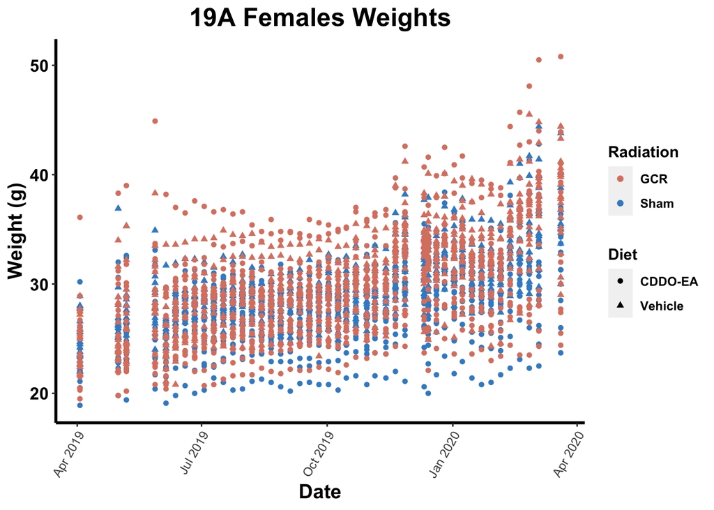

```r
ggplot(FemalesWeightsClean, aes(x = Date, y = Weight,
  shape = Diet, color = Radiation, fill = Diet,
  group = interaction(Radiation, Diet))) +
  geom_point() +
  scale_color_manual(values = c("#db8270", "#3e8dcc")) +
  ggtitle("19A Females Weights") +
  ylab("Weight (g)") +
  theme(axis.text.x = element_text(angle = 60, vjust = 1, hjust = 1),
      panel.grid.major = element_blank(), panel.grid.minor = element_blank(),
      plot.title = element_text(hjust = 0.5, face="bold", size = 18),
      panel.background = element_blank(),
      axis.line = element_line(colour = "black", size = 1),
      axis.text.y=element_text(colour = "black", family="Arial", size=12,
                             face="bold"),
      axis.title.x=element_text(face = "bold", size=14),
      axis.title.y=element_text(face = "bold", size=14),
      legend.title=element_text(face="bold"),
      legend.text=element_text(face="bold"))
```

# Test for ANOVA Assumptions

Identify Outliers

```r
FemalesWeightsCleanOutliers <- FemalesWeightsClean %>%
  group_by(Radiation, Diet, Date) %>%
  identify_outliers(Weight)
FemalesWeightsCleanOutliers
```

| Radiation | Diet | Date | Mouse | Weight | is.outlier | is.extreme |
| --- | --- | --- | --- | --- | --- | --- |
| GCR | CDDO-EA | 2019-04-03 | 3048 | 36.1 | TRUE | FALSE |
| GCR | CDDO-EA | 2019-05-01 | 3048 | 38.3 | TRUE | FALSE |
| GCR | CDDO-EA | 2020-01-08 | 3048 | 41.7 | TRUE | FALSE |
| GCR | CDDO-EA | 2020-01-15 | 3048 | 39.2 | TRUE | FALSE |
| GCR | CDDO-EA | 2020-01-22 | 3048 | 39.5 | TRUE | FALSE |
| GCR | Vehicle | 2019-05-07 | 3061 | 35.3 | TRUE | FALSE |
| GCR | Vehicle | 2019-06-05 | 3061 | 33.6 | TRUE | FALSE |
| GCR | Vehicle | 2019-06-12 | 3061 | 33.6 | TRUE | FALSE |
| GCR | Vehicle | 2019-07-10 | 3061 | 34.2 | TRUE | FALSE |
| GCR | Vehicle | 2019-07-17 | 3061 | 34.9 | TRUE | FALSE |

[output cut: 138 more lines]

Test for Normality of Distributions at Each Date

```r
FemalesWeightsClean %>%
  group_by(Radiation, Diet, Date) %>%
  shapiro_test(Weight)
```

| Radiation | Diet | Date | variable | statistic | p |
| --- | --- | --- | --- | --- | --- |
| GCR | CDDO-EA | 2019-04-03 | Weight | 0.8485047 | 0.016540879 |
| GCR | CDDO-EA | 2019-05-01 | Weight | 0.9238962 | 0.220803406 |
| GCR | CDDO-EA | 2019-05-07 | Weight | 0.9113300 | 0.141920202 |
| GCR | CDDO-EA | 2019-05-28 | Weight | 0.9071875 | 0.122610522 |
| GCR | CDDO-EA | 2019-06-05 | Weight | 0.8990198 | 0.091949152 |
| GCR | CDDO-EA | 2019-06-12 | Weight | 0.9230553 | 0.214408850 |
| GCR | CDDO-EA | 2019-06-19 | Weight | 0.9199916 | 0.192577611 |
| GCR | CDDO-EA | 2019-06-26 | Weight | 0.9177946 | 0.178260877 |
| GCR | CDDO-EA | 2019-07-03 | Weight | 0.9670066 | 0.811520761 |
| GCR | CDDO-EA | 2019-07-10 | Weight | 0.9707250 | 0.868644137 |

[output cut: 170 more lines]

Visualize Distributions by QQPlots by Increasing Dates

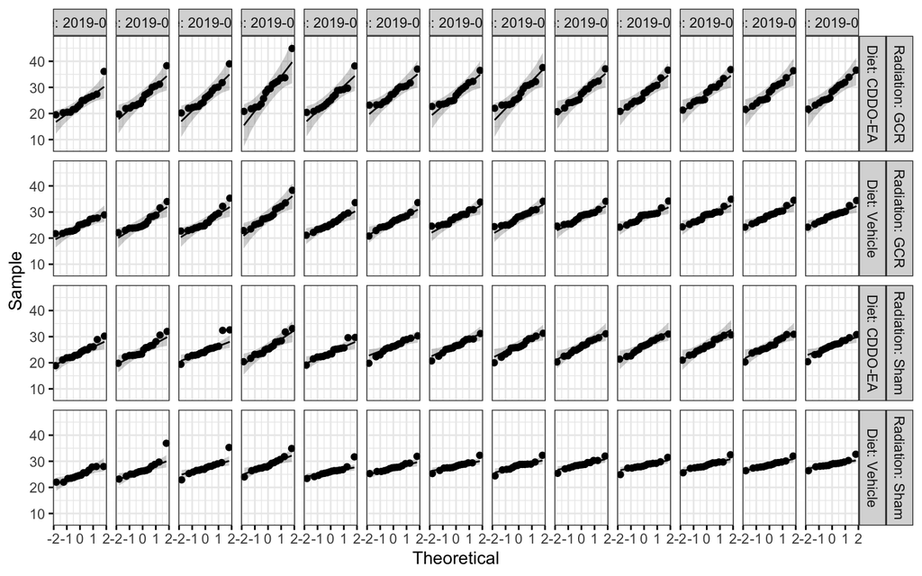

```r
FemalesClean1 <- FemalesWeightsClean %>% filter(Date <= '2019-07-31')
FemalesClean2 <- FemalesWeightsClean %>% filter(Date > '2019-07-31' &
                                                  Date <= '2019-10-30')
FemalesClean3 <- FemalesWeightsClean %>% filter(Date > '2019-10-30' &
                                                  Date <= '2020-01-08')
FemalesClean4 <- FemalesWeightsClean %>% filter(Date > '2020-01-08')

ggqqplot(FemalesClean1, "Weight", ggtheme = theme_bw()) +
  facet_grid(Radiation + Diet ~ Date,
             labeller = "label_both")
```

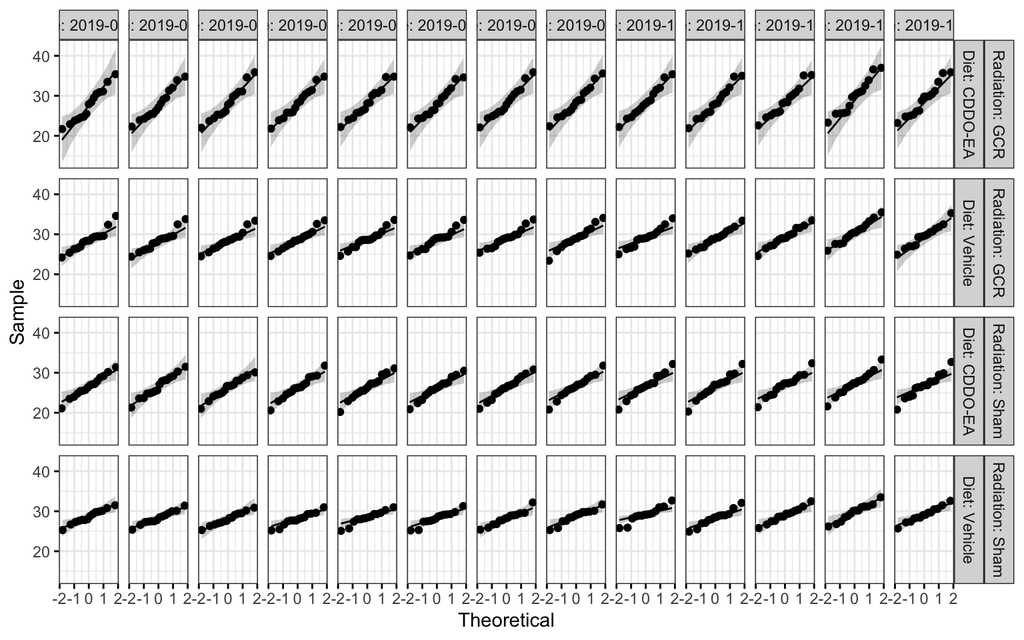

```r
ggqqplot(FemalesClean2, "Weight", ggtheme = theme_bw()) +
  facet_grid(Radiation + Diet ~ Date,
             labeller = "label_both")
```

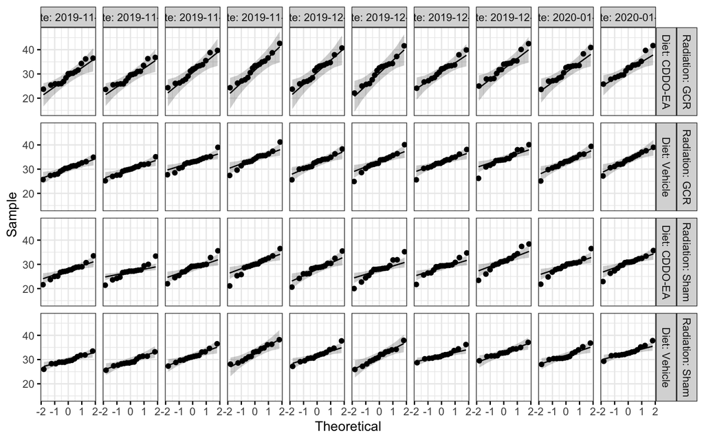

```r
ggqqplot(FemalesClean3, "Weight", ggtheme = theme_bw()) +
  facet_grid(Radiation + Diet ~ Date,
             labeller = "label_both")
```

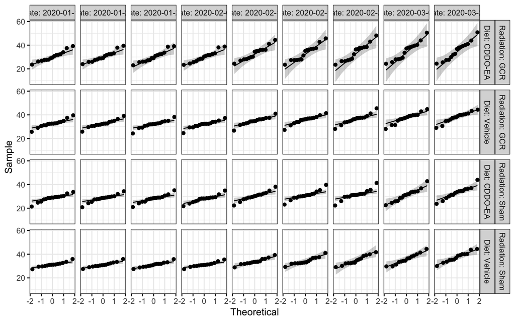

```r
ggqqplot(FemalesClean4, "Weight", ggtheme = theme_bw()) +
  facet_grid(Radiation + Diet ~ Date,
             labeller = "label_both")
```

Test for Homogeneity of Variance

```r
HomVar <- FemalesWeightsClean %>%
  group_by(Date)

HomVarRad <- HomVar %>%
  levene_test(Weight ~ Radiation)

HomVarDiet <- HomVar %>%
  levene_test(Weight ~ Diet)

HomVarRad
```

| Date | df1 | df2 | statistic | p |
| --- | --- | --- | --- | --- |
| 2019-04-03 | 1 | 59 | 1.3136768 | 0.25635744 |
| 2019-05-01 | 1 | 59 | 0.9889515 | 0.32405992 |
| 2019-05-07 | 1 | 59 | 1.2485357 | 0.26836184 |
| 2019-05-28 | 1 | 59 | 2.9801375 | 0.08952559 |
| 2019-06-05 | 1 | 59 | 2.8630327 | 0.09591200 |
| 2019-06-12 | 1 | 59 | 3.6208192 | 0.06194398 |
| 2019-06-19 | 1 | 59 | 3.7523057 | 0.05752727 |
| 2019-06-26 | 1 | 59 | 3.1449715 | 0.08132243 |
| 2019-07-03 | 1 | 59 | 1.6858204 | 0.19920521 |
| 2019-07-10 | 1 | 59 | 2.2498948 | 0.13895599 |

[output cut: 35 more lines]

```r
HomVarDiet
```

| Date | df1 | df2 | statistic | p |
| --- | --- | --- | --- | --- |
| 2019-04-03 | 1 | 59 | 2.6318937 | 0.110068863 |
| 2019-05-01 | 1 | 59 | 1.4802786 | 0.228575720 |
| 2019-05-07 | 1 | 59 | 0.9026374 | 0.345951217 |
| 2019-05-28 | 1 | 59 | 3.6402884 | 0.061267268 |
| 2019-06-05 | 1 | 59 | 2.8884477 | 0.094483968 |
| 2019-06-12 | 1 | 59 | 2.3921710 | 0.127291736 |
| 2019-06-19 | 1 | 59 | 5.0738465 | 0.028023176 |
| 2019-06-26 | 1 | 59 | 5.0324188 | 0.028645391 |
| 2019-07-03 | 1 | 59 | 8.4343707 | 0.005173852 |
| 2019-07-10 | 1 | 59 | 8.5301952 | 0.004941471 |

[output cut: 35 more lines]

# Repeated Measures 3-Way ANOVA

Repeated Measures ANOVA with Greenhouse-Geisser Corrections for Spherecity

```r
FemalesANOVA <- anova_test(
  data = FemalesWeightsClean, Weight ~ Radiation * Diet * Date, wid = Mouse,
  within = Date
)
get_anova_table(FemalesANOVA)
```

|  | Effect | DFn | DFd | F | p | p<.05 | ges |
| --- | --- | --- | --- | --- | --- | --- | --- |
| 1 | Radiation | 2 | 2736 | 62.249 | 3.65e-27 | * | 0.044000 |
| 2 | Diet | 2 | 2736 | 105.667 | 6.25e-45 | * | 0.072000 |
| 3 | Date | 1 | 2736 | 1212.359 | 3.28e-220 | * | 0.307000 |
| 4 | Radiation:Diet | 1 | 2736 | 35.007 | 3.69e-09 | * | 0.013000 |
| 5 | Radiation:Date | 1 | 2736 | 16.718 | 4.46e-05 | * | 0.006000 |
| 6 | Diet:Date | 1 | 2736 | 23.469 | 1.34e-06 | * | 0.009000 |
| 7 | Radiation:Diet:Date | 1 | 2736 | 0.530 | 4.67e-01 |  | 0.000194 |

Because our data contains missing samples due to animal deaths, a mixed model is preferred:

Repeated Measures 3-Way Mixed Model ANOVA

```r
FemalesMMANOVA <- anova_test(
  data = FemalesWeightsClean, dv = Weight, between = c(Radiation, Diet),
  within = Date, wid = Mouse
)
get_anova_table(FemalesMMANOVA)
```

|  | Effect | DFn | DFd | F | p | p<.05 | ges |
| --- | --- | --- | --- | --- | --- | --- | --- |
| 1 | Radiation | 1.00 | 56.00 | 2.530 | 1.17e-01 |  | 0.036 |
| 2 | Diet | 1.00 | 56.00 | 5.095 | 2.80e-02 | * | 0.070 |
| 3 | Date | 4.35 | 243.64 | 185.296 | 1.02e-75 | * | 0.371 |
| 4 | Radiation:Diet | 1.00 | 56.00 | 1.043 | 3.12e-01 |  | 0.015 |
| 5 | Radiation:Date | 4.35 | 243.64 | 2.692 | 2.80e-02 | * | 0.009 |
| 6 | Diet:Date | 4.35 | 243.64 | 3.710 | 5.00e-03 | * | 0.012 |
| 7 | Radiation:Diet:Date | 4.35 | 243.64 | 0.637 | 6.50e-01 |  | 0.002 |

# Multiple Comparisons

Here are several approaches to multiple comparisons that use different pooling Standard Deviations (SD), depending on which main variables are relevant for comparisons

Multiple Comparisons with Bonferroni Corrections by Diet (pools all Diet SDs)

```r
PairwiseDiet <- FemalesWeightsClean %>%
  group_by(Date, Radiation) %>%
  pairwise_t_test(
    Weight ~ Diet, paired = FALSE,
    p.adjust.method = "bonferroni"
  )
PairwiseDiet
```

|  | Radiation | Date | .y. | group1 | group2 | n1 | n2 | p | p.signif | p.adj | p.adj.signif |
| --- | --- | --- | --- | --- | --- | --- | --- | --- | --- | --- | --- |
| 1 | GCR | 2019-04-03 | Weight | CDDO-EA | Vehicle | 15 | 16 | 0.60200 | ns | 0.60200 | ns |
| 2 | Sham | 2019-04-03 | Weight | CDDO-EA | Vehicle | 16 | 14 | 0.32200 | ns | 0.32200 | ns |
| 3 | GCR | 2019-05-01 | Weight | CDDO-EA | Vehicle | 15 | 16 | 0.83400 | ns | 0.83400 | ns |
| 4 | Sham | 2019-05-01 | Weight | CDDO-EA | Vehicle | 16 | 14 | 0.10500 | ns | 0.10500 | ns |
| 5 | GCR | 2019-05-07 | Weight | CDDO-EA | Vehicle | 15 | 16 | 0.99200 | ns | 0.99200 | ns |
| 6 | Sham | 2019-05-07 | Weight | CDDO-EA | Vehicle | 16 | 14 | 0.02830 | * | 0.02830 | * |
| 7 | GCR | 2019-05-28 | Weight | CDDO-EA | Vehicle | 15 | 16 | 0.93100 | ns | 0.93100 | ns |
| 8 | Sham | 2019-05-28 | Weight | CDDO-EA | Vehicle | 16 | 14 | 0.01560 | * | 0.01560 | * |
| 9 | GCR | 2019-06-05 | Weight | CDDO-EA | Vehicle | 15 | 16 | 0.91100 | ns | 0.91100 | ns |
| 10 | Sham | 2019-06-05 | Weight | CDDO-EA | Vehicle | 16 | 14 | 0.03030 | * | 0.03030 | * |

[output cut: 80 more lines]

Multiple Comparisons with Bonferroni Corrections by Radiation (pools all Radiation SDs)

```r
PairwiseRad <- FemalesWeightsClean %>%
  group_by(Date, Diet) %>%
  pairwise_t_test(
    Weight ~ Radiation, paired = FALSE,
    p.adjust.method = "bonferroni"
  )
PairwiseRad
```

|  | Diet | Date | .y. | group1 | group2 | n1 | n2 | p | p.signif | p.adj | p.adj.signif |
| --- | --- | --- | --- | --- | --- | --- | --- | --- | --- | --- | --- |
| 1 | CDDO-EA | 2019-04-03 | Weight | GCR | Sham | 15 | 16 | 0.9450 | ns | 0.9450 | ns |
| 2 | Vehicle | 2019-04-03 | Weight | GCR | Sham | 16 | 14 | 0.8010 | ns | 0.8010 | ns |
| 3 | CDDO-EA | 2019-05-01 | Weight | GCR | Sham | 15 | 16 | 0.3730 | ns | 0.3730 | ns |
| 4 | Vehicle | 2019-05-01 | Weight | GCR | Sham | 16 | 14 | 0.4180 | ns | 0.4180 | ns |
| 5 | CDDO-EA | 2019-05-07 | Weight | GCR | Sham | 15 | 16 | 0.3410 | ns | 0.3410 | ns |
| 6 | Vehicle | 2019-05-07 | Weight | GCR | Sham | 16 | 14 | 0.3290 | ns | 0.3290 | ns |
| 7 | CDDO-EA | 2019-05-28 | Weight | GCR | Sham | 15 | 16 | 0.1170 | ns | 0.1170 | ns |
| 8 | Vehicle | 2019-05-28 | Weight | GCR | Sham | 16 | 14 | 0.9040 | ns | 0.9040 | ns |
| 9 | CDDO-EA | 2019-06-05 | Weight | GCR | Sham | 15 | 16 | 0.1900 | ns | 0.1900 | ns |
| 10 | Vehicle | 2019-06-05 | Weight | GCR | Sham | 16 | 14 | 0.7110 | ns | 0.7110 | ns |

[output cut: 80 more lines]

Format Data for Multi-Variable Multiple Comparisons

```r
FemalesWeightsClean$Group <- paste(FemalesWeightsClean$Diet,
                                   FemalesWeightsClean$Radiation)
head(FemalesWeightsClean)
```

| Mouse | Radiation | Diet | Date | Weight | Group |
| --- | --- | --- | --- | --- | --- |
| 3069 | Sham | CDDO-EA | 2019-04-03 | 24.1 | CDDO-EA Sham |
| 3069 | Sham | CDDO-EA | 2019-05-01 | 25.0 | CDDO-EA Sham |
| 3069 | Sham | CDDO-EA | 2019-05-07 | 25.2 | CDDO-EA Sham |
| 3069 | Sham | CDDO-EA | 2019-05-28 | 26.0 | CDDO-EA Sham |
| 3069 | Sham | CDDO-EA | 2019-06-05 | 25.3 | CDDO-EA Sham |
| 3069 | Sham | CDDO-EA | 2019-06-12 | 26.2 | CDDO-EA Sham |

Multiple Comparisons with Bonferroni Corrections Across Diet and Radiation (pools all SDs)

```r
PairwiseAll <- FemalesWeightsClean %>%
  group_by(Date) %>%
  pairwise_t_test(
    Weight ~ Group, paired = FALSE,
    p.adjust.method = "bonferroni"
  )
PairwiseAll #%>% filter (group1 == "2019-04-03")
```

|  | Date | .y. | group1 | group2 | n1 | n2 | p | p.signif | p.adj | p.adj.signif |
| --- | --- | --- | --- | --- | --- | --- | --- | --- | --- | --- |
| 1 | 2019-04-03 | Weight | CDDO-EA GCR | CDDO-EA Sham | 15 | 16 | 0.933000 | ns | 1.00000 | ns |
| 2 | 2019-04-03 | Weight | CDDO-EA GCR | Vehicle GCR | 15 | 16 | 0.555000 | ns | 1.00000 | ns |
| 3 | 2019-04-03 | Weight | CDDO-EA Sham | Vehicle GCR | 16 | 16 | 0.493000 | ns | 1.00000 | ns |
| 4 | 2019-04-03 | Weight | CDDO-EA GCR | Vehicle Sham | 15 | 14 | 0.451000 | ns | 1.00000 | ns |
| 5 | 2019-04-03 | Weight | CDDO-EA Sham | Vehicle Sham | 16 | 14 | 0.397000 | ns | 1.00000 | ns |
| 6 | 2019-04-03 | Weight | Vehicle GCR | Vehicle Sham | 16 | 14 | 0.852000 | ns | 1.00000 | ns |
| 7 | 2019-05-01 | Weight | CDDO-EA GCR | CDDO-EA Sham | 15 | 16 | 0.326000 | ns | 1.00000 | ns |
| 8 | 2019-05-01 | Weight | CDDO-EA GCR | Vehicle GCR | 15 | 16 | 0.816000 | ns | 1.00000 | ns |
| 9 | 2019-05-01 | Weight | CDDO-EA Sham | Vehicle GCR | 16 | 16 | 0.445000 | ns | 1.00000 | ns |
| 10 | 2019-05-01 | Weight | CDDO-EA GCR | Vehicle Sham | 15 | 14 | 0.621000 | ns | 1.00000 | ns |

[output cut: 260 more lines]

Multiple Comparisons with Bonferroni Corrections Across Diet and Radiation (Does not pool SDs)

```r
PairwiseAll <- FemalesWeightsClean %>%
  group_by(Date) %>%
  t_test(
    Weight ~ Group, paired = FALSE,
    p.adjust.method = "bonferroni"
  )
PairwiseAll
```

|  | Date | .y. | group1 | group2 | n1 | n2 | statistic | df | p | p.adj | p.adj.signif |
| --- | --- | --- | --- | --- | --- | --- | --- | --- | --- | --- | --- |
| 1 | 2019-04-03 | Weight | CDDO-EA GCR | CDDO-EA Sham | 15 | 16 | 0.069264834 | 24.50967 | 0.945000 | 1.000 | ns |
| 2 | 2019-04-03 | Weight | CDDO-EA GCR | Vehicle GCR | 15 | 16 | -0.517319017 | 21.39732 | 0.610000 | 1.000 | ns |
| 3 | 2019-04-03 | Weight | CDDO-EA GCR | Vehicle Sham | 15 | 14 | -0.690524387 | 20.58204 | 0.498000 | 1.000 | ns |
| 4 | 2019-04-03 | Weight | CDDO-EA Sham | Vehicle GCR | 16 | 16 | -0.789767690 | 28.66832 | 0.436000 | 1.000 | ns |
| 5 | 2019-04-03 | Weight | CDDO-EA Sham | Vehicle Sham | 16 | 14 | -1.031263794 | 26.99960 | 0.312000 | 1.000 | ns |
| 6 | 2019-04-03 | Weight | Vehicle GCR | Vehicle Sham | 16 | 14 | -0.256652612 | 27.98801 | 0.799000 | 1.000 | ns |
| 7 | 2019-05-01 | Weight | CDDO-EA GCR | CDDO-EA Sham | 15 | 16 | 0.894029042 | 24.28825 | 0.380000 | 1.000 | ns |
| 8 | 2019-05-01 | Weight | CDDO-EA GCR | Vehicle GCR | 15 | 16 | 0.209261861 | 24.64597 | 0.836000 | 1.000 | ns |
| 9 | 2019-05-01 | Weight | CDDO-EA GCR | Vehicle Sham | 15 | 14 | -0.449576859 | 24.99945 | 0.657000 | 1.000 | ns |
| 10 | 2019-05-01 | Weight | CDDO-EA Sham | Vehicle GCR | 16 | 16 | -0.875663241 | 29.98294 | 0.388000 | 1.000 | ns |

[output cut: 260 more lines]

# Effect Sizes

Main Effect Size (Eta Squared)

```r
FemaleWeightsES <- FemalesWeightsClean %>%
  group_by(Date) %>%
  convert_as_factor(Date)
eta_squared(aov(Weight ~ Radiation * Diet, data = FemalesWeightsClean))
```

```
##      Radiation           Diet Radiation:Diet
##    0.023913138    0.041078681    0.008172795
```

Multiple Comparisons Effect Size (Cohen’s d)

```r
cohens_d(Weight ~ Group, data = FemaleWeightsES)
```

|  | .y. | group1 | group2 | effsize | Date | n1 | n2 | magnitude |
| --- | --- | --- | --- | --- | --- | --- | --- | --- |
| 1 | Weight | CDDO-EA GCR | CDDO-EA Sham | 0.025040008 | 2019-04-03 | 15 | 16 | negligible |
| 2 | Weight | CDDO-EA GCR | Vehicle GCR | -0.187531821 | 2019-04-03 | 15 | 16 | negligible |
| 3 | Weight | CDDO-EA GCR | Vehicle Sham | -0.253862974 | 2019-04-03 | 15 | 14 | small |
| 4 | Weight | CDDO-EA Sham | Vehicle GCR | -0.279225044 | 2019-04-03 | 16 | 16 | small |
| 5 | Weight | CDDO-EA Sham | Vehicle Sham | -0.373300644 | 2019-04-03 | 16 | 14 | small |
| 6 | Weight | Vehicle GCR | Vehicle Sham | -0.093558038 | 2019-04-03 | 16 | 14 | negligible |
| 7 | Weight | CDDO-EA GCR | CDDO-EA Sham | 0.323267001 | 2019-05-01 | 15 | 16 | small |
| 8 | Weight | CDDO-EA GCR | Vehicle GCR | 0.075640966 | 2019-05-01 | 15 | 16 | negligible |
| 9 | Weight | CDDO-EA GCR | Vehicle Sham | -0.166055773 | 2019-05-01 | 15 | 14 | negligible |
| 10 | Weight | CDDO-EA Sham | Vehicle GCR | -0.309593708 | 2019-05-01 | 16 | 16 | small |

[output cut: 260 more lines]

# Figure

Smoothened Line Graph (Mean +/- SEM)

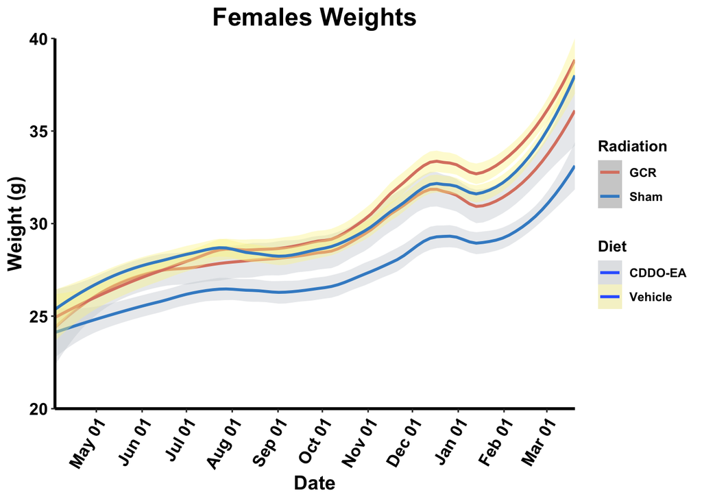

```r
FemalesWeightsGraph <- ggplot(FemalesWeightsClean, aes(x=Date,
    y=Weight, group = interaction(Radiation, Diet),
    fill=Diet, color=Radiation)) +
    geom_point(size = 1, alpha = 0) +
    geom_smooth(span = .4, aes(color=Radiation, fill=Diet)) +
   scale_fill_manual(values = c( "#CACED4", "#FBF293"))+
    scale_color_manual(values = c("#db8270", "#3e8dcc"))+
  ggtitle("Females Weights") +
  ylab("Weight (g)") +
  xlab("Date") +
  scale_y_continuous(expand = c(0,0)) +
  #scale_x_continuous(expand = expansion(mult = c(0,0))) +
  #makes x axis start at 1 if scaled continuously
  coord_cartesian(expand = FALSE, ylim = c(20,40)) +
  #does not remove points outside of y-limit, merges y-axis with line graph
  scale_x_date(date_labels = "%b %d", date_breaks = "1 month") +
  #scales x axis by date, every month
  theme(panel.grid.major = element_blank(), panel.grid.minor = element_blank(),
        axis.text.x = element_text(angle = 60, vjust = 1, hjust = 1),
      plot.title = element_text(hjust = 0.5, face="bold", size = 18),
      panel.background = element_blank(),
      axis.line = element_line(colour = "black", size = 1),
      axis.text=element_text(colour = "black", family="Arial", size=12,
                             face="bold"),
      axis.title.x=element_text(face = "bold", size=14),
      axis.title.y=element_text(face = "bold", size=14),
      legend.title=element_text(face="bold"),
      legend.text=element_text(face="bold"))
print(FemalesWeightsGraph)
```

To Save as SVG:

```r
#library(svglite)
#ggsave("FemalesWeightsGraph.svg", width = 8, height = 4)
```